# Introduction

## Comparization

#### 1. Speed

```python
start_time = time.time()
kmeans = KMeans(n_clusters=3, init='k-means++', algorithm='lloyd', random_state=42).fit(transformed_df)
end_time = time.time()

time_taken = end_time - start_time
print("Time taken by KMeans clustering:", time_taken, "seconds")
```

```
Time taken by KMeans clustering: 0.06981325149536133 seconds
```

```python
start_time = time.time()
hierarchical = AgglomerativeClustering(n_clusters=3, linkage='ward').fit(transformed_df)
end_time = time.time()
time_taken = end_time - start_time
print("Time taken by agglomerative clustering:", time_taken, "seconds")
```

```
Time taken by agglomerative clustering: 0.17261028289794922 seconds
```

#### 2. Memory Usage

```python
process = psutil.Process(os.getpid())
mem_before_kmeans = process.memory_info().rss / 1024 / 1024

kmeans = KMeans(n_clusters=3, init='k-means++', algorithm='lloyd', random_state=42).fit(transformed_df)
process = psutil.Process(os.getpid())
mem_after_kmeans = process.memory_info().rss / 1024 / 1024


mem_kmeans = mem_after_kmeans - mem_before_kmeans

print("Memory usage of k-means model:", mem_kmeans, "MB")
```

```
Memory usage of k-means model: 0.0 MB
```

```python
process = psutil.Process(os.getpid())
mem_before_hierarchical = process.memory_info().rss / 1024 / 1024

hierarchical = AgglomerativeClustering(n_clusters=3, linkage='ward').fit(transformed_df)

process = psutil.Process(os.getpid())
mem_after_hierarchical = process.memory_info().rss / 1024 / 1024

mem_hierarchical = mem_after_hierarchical - mem_before_hierarchical

print("Memory usage of hierarchical model:", mem_hierarchical, "MB")
```

```
Memory usage of hierarchical model: 0.0 MB
```

#### 3. Cluster Quality

```python
#Calinski-Harabasz index
kmeans_score = calinski_harabasz_score(transformed_df, kmeans.labels_)
hierarchical_score = calinski_harabasz_score(transformed_df, hierarchical.labels_)

print("Calinski-Harabasz Index for k-means clustering: ", kmeans_score)
print("Calinski-Harabasz Index for agglomerative clustering: ", hierarchical_score)
```

```
Calinski-Harabasz Index for k-means clustering:  2022.9539722755253
Calinski-Harabasz Index for agglomerative clustering:  1588.0000237080965
```

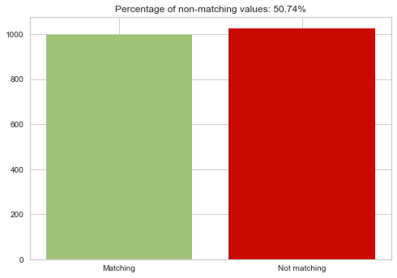

```python
non_match_counts = (df['ClustName'] != df['ClustNameAgg']).value_counts()
percent_non_match = 100 * non_match_counts[True] / len(df)

fig, ax = plt.subplots()
ax.bar(['Matching', 'Not matching'], [len(df) - non_match_counts[True], non_match_counts[True]], color=['g', 'r'])
ax.set_title('Percentage of non-matching values: {:.2f}%'.format(percent_non_match))
plt.show()
```

```python
x= df[df['ClustName'] != df['ClustNameAgg']]
lst = ['LowBuyer', 'HighBuyer', 'MidBuyer']
for buyer in lst:
    print(x[x['ClustName']==buyer]["ClustNameAgg"].unique())
```

```
['HighBuyer']
['MidBuyer' 'LowBuyer']
['HighBuyer' 'LowBuyer']
```

- Interestingliy there are 18 obsevation selected by k-means as a "HighBuyer" which is valued "LowBuyer" in agllomerative
- This might be occured:
  - becuause the nature of the dataset migh more close to k-means algoritm,
  - The difference in the algorithms used by k-means and agglomerative clustering can lead to different results.

```python
x = df[(df['ClustName'] != df['ClustNameAgg']) & (df['ClustName'] == 'HighBuyer') & (df['ClustNameAgg'] == 'LowBuyer')]
x
```

|  | Education | Income | Kidhome | Teenhome | Recency | Wines | Fruits | Meat | Fish | Sweets | ... | Age | TotalSpent | Living_With | Children | Parenthood | Kmeans | ClustName | Total_Promos | Agg | ClustNameAgg |
| --- | --- | --- | --- | --- | --- | --- | --- | --- | --- | --- | --- | --- | --- | --- | --- | --- | --- | --- | --- | --- | --- |
| 90 | 2 | 50150.0 | 0 | 0 | 32 | 135 | 46 | 92 | 65 | 61 | ... | 40 | 410 | 1 | 0 | 0 | 2 | HighBuyer | 0 | 0 | LowBuyer |
| 116 | 0 | 71488.0 | 0 | 0 | 87 | 162 | 33 | 124 | 40 | 28 | ... | 58 | 559 | 1 | 0 | 0 | 2 | HighBuyer | 0 | 0 | LowBuyer |
| 669 | 0 | 41039.0 | 0 | 0 | 32 | 34 | 11 | 137 | 179 | 61 | ... | 41 | 467 | 1 | 0 | 0 | 2 | HighBuyer | 0 | 0 | LowBuyer |
| 685 | 1 | 45938.0 | 0 | 0 | 46 | 273 | 11 | 178 | 62 | 83 | ... | 62 | 636 | 0 | 0 | 0 | 2 | HighBuyer | 0 | 0 | LowBuyer |
| 700 | 1 | 58398.0 | 0 | 0 | 44 | 299 | 5 | 201 | 21 | 21 | ... | 70 | 596 | 1 | 0 | 0 | 2 | HighBuyer | 0 | 0 | LowBuyer |
| 818 | 1 | 48789.0 | 0 | 0 | 94 | 351 | 16 | 156 | 7 | 5 | ... | 31 | 680 | 0 | 0 | 0 | 2 | HighBuyer | 0 | 0 | LowBuyer |
| 890 | 1 | 57100.0 | 0 | 0 | 19 | 181 | 21 | 69 | 39 | 3 | ... | 50 | 409 | 1 | 0 | 0 | 2 | HighBuyer | 0 | 0 | LowBuyer |
| 932 | 2 | 51563.0 | 0 | 0 | 60 | 1166 | 0 | 48 | 0 | 0 | ... | 36 | 1250 | 1 | 0 | 0 | 2 | HighBuyer | 2 | 0 | LowBuyer |
| 1049 | 2 | 42000.0 | 0 | 0 | 23 | 124 | 83 | 267 | 85 | 59 | ... | 36 | 653 | 0 | 0 | 0 | 2 | HighBuyer | 0 | 0 | LowBuyer |
| 1104 | 2 | 36262.0 | 0 | 0 | 24 | 88 | 39 | 54 | 64 | 28 | ... | 40 | 426 | 1 | 0 | 0 | 2 | HighBuyer | 1 | 0 | LowBuyer |
| 1412 | 1 | 31907.0 | 0 | 0 | 75 | 33 | 87 | 64 | 175 | 16 | ... | 51 | 449 | 0 | 0 | 0 | 2 | HighBuyer | 0 | 0 | LowBuyer |
| 1442 | 2 | 38410.0 | 0 | 0 | 65 | 153 | 64 | 123 | 116 | 64 | ... | 49 | 534 | 1 | 0 | 0 | 2 | HighBuyer | 0 | 0 | LowBuyer |
| 1610 | 2 | 41003.0 | 0 | 0 | 11 | 123 | 133 | 142 | 71 | 44 | ... | 60 | 601 | 0 | 0 | 0 | 2 | HighBuyer | 0 | 0 | LowBuyer |
| 1627 | 0 | 75774.0 | 1 | 0 | 27 | 340 | 21 | 134 | 258 | 14 | ... | 42 | 823 | 1 | 1 | 1 | 2 | HighBuyer | 0 | 0 | LowBuyer |
| 1846 | 1 | 70886.0 | 1 | 0 | 65 | 407 | 70 | 239 | 103 | 88 | ... | 52 | 960 | 1 | 1 | 1 | 2 | HighBuyer | 0 | 0 | LowBuyer |
| 1959 | 0 | 32632.0 | 0 | 0 | 32 | 63 | 151 | 137 | 153 | 19 | ... | 60 | 576 | 1 | 0 | 0 | 2 | HighBuyer | 0 | 0 | LowBuyer |
| 1970 | 1 | 51373.0 | 0 | 0 | 37 | 83 | 2 | 101 | 64 | 26 | ... | 32 | 393 | 1 | 0 | 0 | 2 | HighBuyer | 0 | 0 | LowBuyer |
| 2023 | 1 | 49767.0 | 0 | 0 | 92 | 202 | 47 | 197 | 55 | 42 | ... | 32 | 692 | 0 | 0 | 0 | 2 | HighBuyer | 0 | 0 | LowBuyer |

18 rows × 34 columns

- The other assumptions:
  - The 18 observations, may have unique combinations of demographic and behavioral characteristics that make them more similar to one group of customers than another. But after carefully analyzing the 18 observation, any unique combination couldn't be found.
  - Secondly, there could be errors or noise in the data that affect the clustering results. But careful consideration missing or inaccurate couldn't be found.

## Conclusion

This thesis statement examines a hybrid segmentation approach that consists of the demographic and behavioral analysis of customers by using clustering methods in unsupervised machine learning algorithms, which allows marketing professionals to find patterns and insights with the inference of customer clusters based on the clients demographic and purchasing behavior characteristics. In this particular grocery store setting in the retailing sector, the analysis revealed that customers with a broad range of spending habits were more responsive to the store's campaigns than those with medium and low spending habits. Furthermore, partition-based and hierarchical clustering models were analyzed, and it was found that KMeans performed better than agglomerative models with the consideration of the provided dataset’s limitations. This thesis concludes itself with the aim of supporting other studies in clustering methods in customer segmentation projects and demonstrating to current organizations the potential impact of clustering models on customer segmentation procedures. In the future, new data structures and frameworks will continue to evolve in the literature and the related industries, allowing for even deeper and larger datasets to be analyzed while finding admires the related improvements.